# Block groups

#### Intersection of block groups with community districts

Each community district will reside entirely inside a single county, and it is obvious to anyone familiar with the Kansas City metropolitan area which county is would be, so this is done mostly for the sake of continuity and completeness.

It is important that both the block groups and the community districts use a common coordinate reference system. It is unclear WHICH coordinate reference system is best, but this is controlled by the st_crs function of the sf package.

The st_intersects function will evaluate to TRUE if two shapefiles intersect. The st_area function will give the area of a shapefile and the st_intersection function will produce a new shapefile from the intersection of two shapefiles.

```
## st_as_s2(): dropping Z and/or M coordinate
```

```
## Units: [1]
##  [1] 0.8919314491 1.0000000000 1.0000000000 1.0000000000 0.3360845572
##  [6] 1.0000000001 1.0000000000 1.0000000000 0.9999999998 0.0004908059
## [11] 0.4827698283 0.9999999999 0.9726611038 0.9979748986 0.9983786472
## [16] 1.0000000000 0.0007993012 0.0014767254 0.9994267659 0.8436013738
## [21] 0.9999999988 0.5831785466 1.0000000000 0.0003487969 0.0102926008
## [26] 0.9792292668 0.7452778736 1.0000000000 1.0000000000 0.9999999999
## [31] 0.9999999994 0.9982864091 1.0000000000 1.0000000000 0.9999999995
## [36] 1.0000000002 0.9999999994 1.0000000000 0.9857716047 0.8766213657
## [41] 0.9984922554 1.0000000000 0.9983804715 0.0122309475 0.0008199949
## [46] 0.9775101995 0.9802956244 0.9999999998 1.0000000001 1.0000000000
## [51] 0.9999999997 1.0000000005 0.9991345668
```

```
## st_as_s2(): dropping Z and/or M coordinate
```

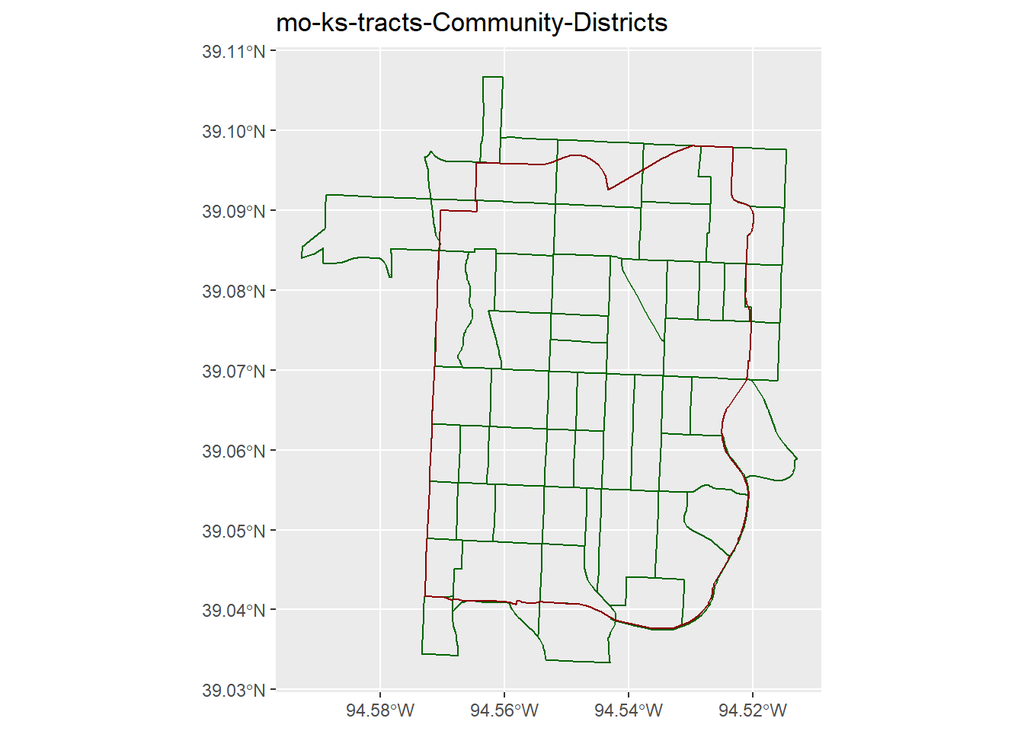

```
## Units: [1]
##  [1] 0.9991560441 0.0014672813 0.9995091945 0.2218381965 1.0000000004
##  [6] 0.0561385203 1.0000000000 0.0593164140 0.0003787736 0.9999585726
## [11] 0.0196423886 1.0000000000 1.0000000000 0.1562664184 0.4168214551
## [16] 1.0000000000 0.9999999998 1.0000000043 0.9997678140 1.0000000000
## [21] 1.0000000000 1.0000000000 0.9996103321 1.0000000000 1.0000000000
## [26] 0.9999999995 1.0000000000 0.9984234975 1.0000000001 0.7455112059
## [31] 0.9967653329 0.3626498105 1.0000000000 0.9999999999 0.9999999999
## [36] 1.0000000001 1.0000000000
```

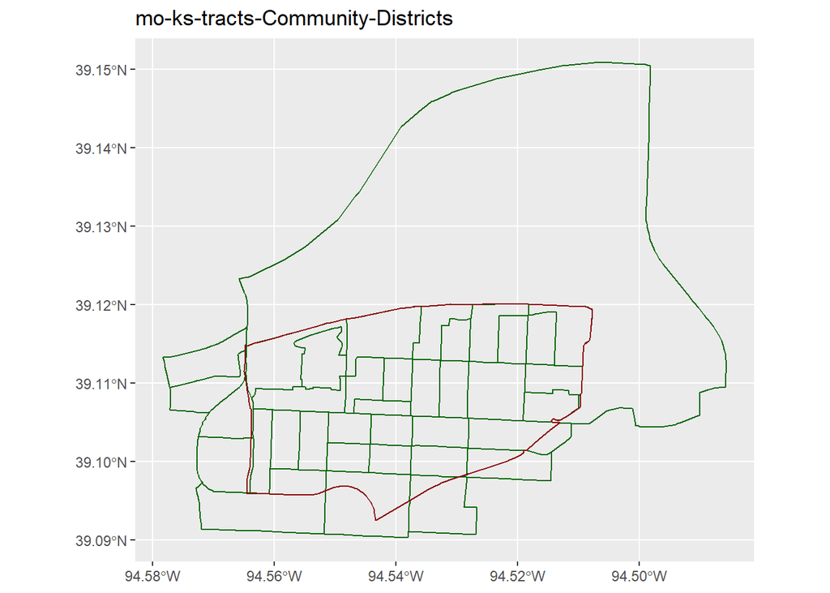

```r
for (i in 1:2) {
mo_ks_bg                      %>%
  st_intersects( cd[i,], sparse=FALSE) -> intersect_matrix
  total_area  <- st_area(mo_ks_bg[intersect_matrix,]) / 1000000
  intersect_area <- st_area(st_intersection(mo_ks_bg[intersect_matrix,],cd[i,])) / 1000000
  print(intersect_area/total_area)
 mo_ks_bg[intersect_matrix,]               %>%
 ggplot(aes())                                  +
        geom_sf(fill=NA, col="darkgreen") +
        geom_sf(data=cd[i, ], fill=NA, col="darkred") +
        ggtitle("mo-ks-tracts-Community-Districts") -> map
  print(map)}
```